# Homework 1

Elizabeth Heeren

2021-03-25

In this homework, you will use `diamonds` data set from `ggplot2` package. It is automatically loaded when you execute `library(ggplot2)` so you don’t have to separately load it. Please create a duplicate of `diamonds` and use that for homework. This will avoid corrupting the original data set.

```r
d <- diamonds # Create a duplicate copy of diamonds data
```

Make sure that you understand the variables in the data by checking the help file by executing `help(diamonds)` in the console. The data has five variables that measure the dimensions.

## Instructions

1. You are expected to recreate each plot **exactly** as shown in the example document.
2. The objective of this homework is to help you develop fine grain control over `ggplot2`. As such, please refrain from exercising artistic freedom!
3. All the plots use `theme_minimal()`.

```r
theme_set(theme_minimal()) # Set document theme to theme_minimal
```

## Q1 (3 points)

Recreate the graph. The parameter that controls transparency is set at 0.3. You need not get exactly the same colors but they must be **discrete** and should not follow a color gradient.

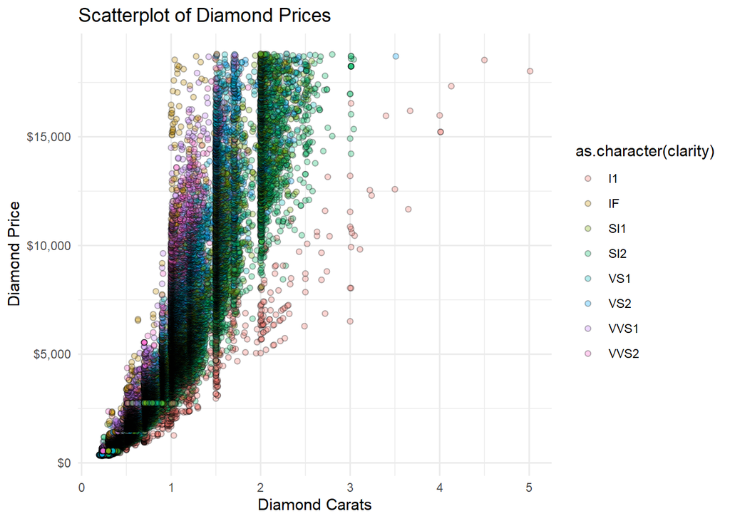

```r
p1 <- ggplot(d, aes(carat, price)) +
geom_point(aes(fill = as.character(clarity)),
             color = "black",                            # color of stroke
             shape = 21,
            alpha = .3) +
scale_y_continuous(labels = scales::dollar_format(prefix = "$")) +
labs(title = "Scatterplot of Diamond Prices",
        x = "Diamond Carats",
        y = "Diamond Price")
print(p1)
```

## Q2 (2 points)

The previous graph looks cluttered. So you decided to use facets instead. Recreate the graph:

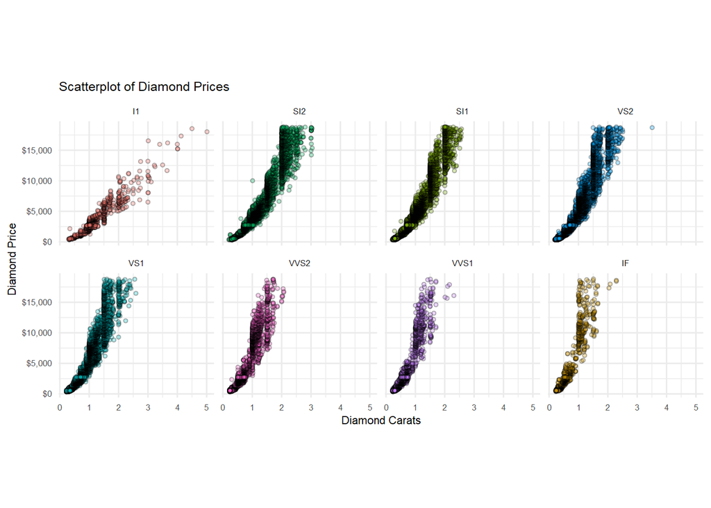

```r
p2 <- ggplot(d, aes(carat, price)) +
  geom_point(aes(fill = as.character(clarity)),
             color = "black",                            # color of stroke
             shape = 21,
             size = 1,
            alpha = .3) +
  scale_y_continuous(labels = scales::dollar_format(prefix = "$")) +
  labs(title = "Scatterplot of Diamond Prices",
        x = "Diamond Carats",
        y = "Diamond Price") +
  facet_wrap(~ clarity, nrow = 2, ncol = 4) +
  theme(legend.position = "none", aspect.ratio = .8, plot.title = element_text(size = 9), strip.text = element_text(size = 6), axis.title = element_text(size = 8), axis.text = element_text(size = 6))
axis.line = element_line

print(p2)
```

## Q3 (5 points)

Next, you want to know whether the price of diamonds depends on table and depth. Note the line types. Recreate the graphs:

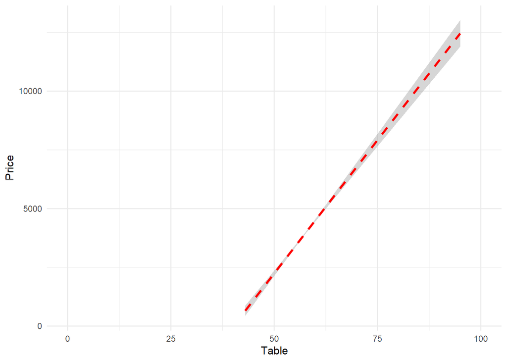

```r
p3.1 <- ggplot(d, aes(table, price)) +
  geom_smooth(method = "lm", linetype = "dashed", col = "red") +
  scale_x_continuous(limits = c(0, 100),  # limits increase or decrease your axis limits (increase left hand area)
                     breaks = c(0, 25, 50, 75, 100)) +
  labs(x = "Table",
       y = "Price")

print(p3.1)
```

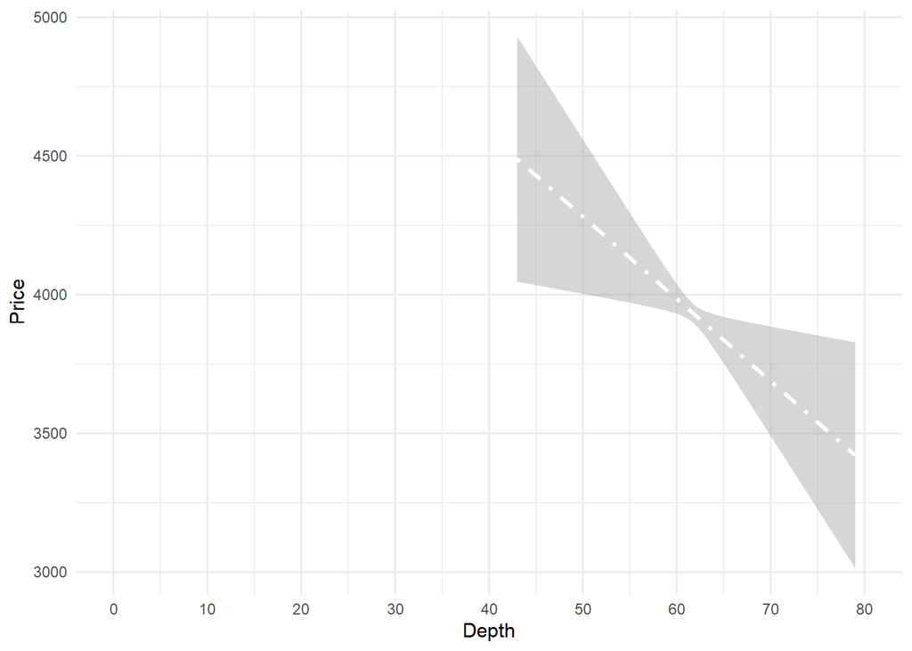

```r
p3.2 <- ggplot(d, aes(depth, price)) +
  geom_smooth(method = "lm", linetype = "dotdash", col = "white") +
  scale_x_continuous(limits = c(0, 80),  # limits increase or decrease your axis limits (increase left hand area)
                     breaks = c(0, 10, 20, 30, 40, 50, 60, 70, 80)) +
  labs(x = "Depth",
       y = "Price")

print(p3.2)
```

## Q4 (5 points)

Recreate each of the graphs for data exploration:

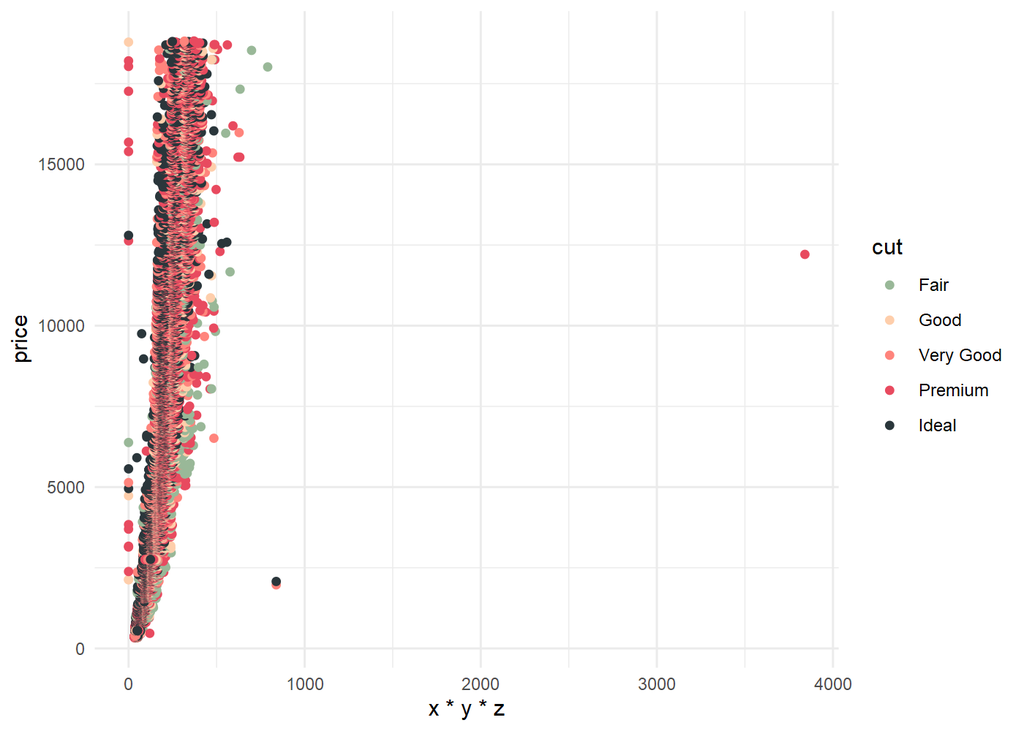

```r
p5.1 <- ggplot(d, aes(x*y*z, price)) +
  geom_point(aes(color = cut)) +
  scale_color_manual(values=c("#99B898", "#FECEAB", "#FF847C", "#E84A5F", "#2A363B"))

print(p5.1)
```

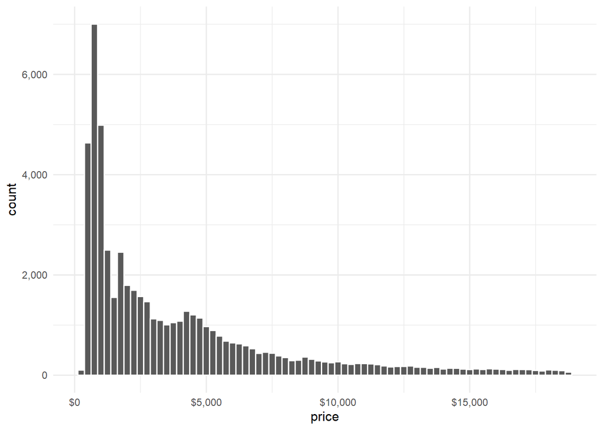

```r
p5.2 <- ggplot(d, aes(price)) +
  geom_histogram(bins = 75, col = "white") +
  scale_x_continuous(limits = c(0, 17500),  # limits increase or decrease your axis limits (increase left hand area)
                     breaks = c(5000, 10000, 15000)) +
  scale_x_continuous(labels = scales::dollar_format(prefix = "$")) +
  scale_y_continuous(labels = scales::comma_format())

print(p5.2)
```

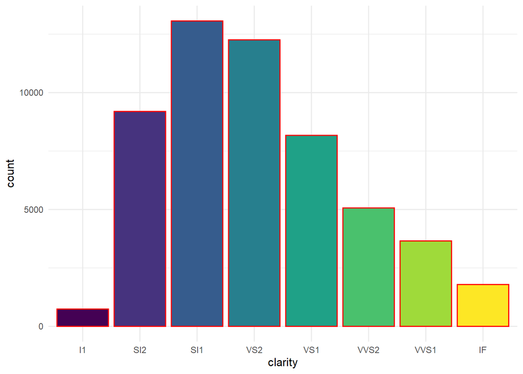

```r
p5.3 <- ggplot(d, aes(clarity)) +
  geom_bar(aes(fill = clarity), col = "red") +
  theme(legend.position = "none")



print(p5.3)
```

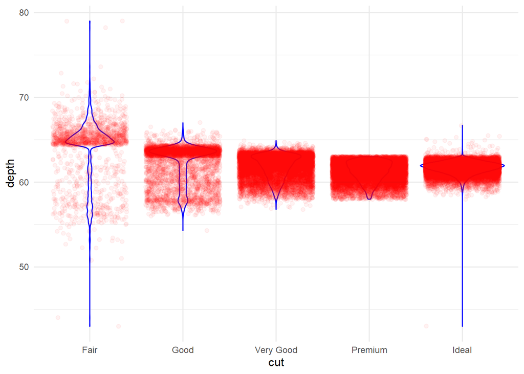

```r
p5.4 <- ggplot(d, aes(cut, depth)) +
  geom_violin(color = "blue") +
  theme(legend.position = "none") +
  geom_jitter(color = "red", alpha = .05)



print(p5.4)
```

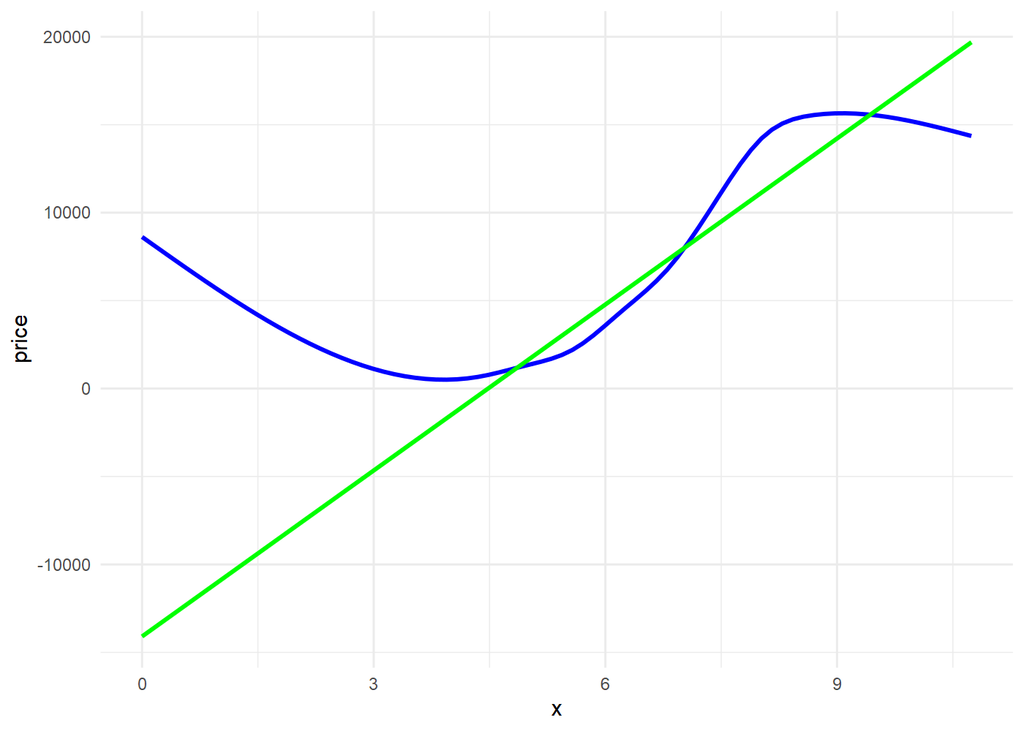

```r
p5.5 <- ggplot(d, aes(x, price)) +
  geom_smooth(method = NULL, se = FALSE, col = "blue") +
  geom_smooth(method = "lm", col = "green") +
  scale_x_continuous(breaks = c(0, 3, 6, 9))



print(p5.5)
```